# us_retail_timeseries

### time series methods - US Retail example

## Import Modules

```python
import numpy as np
import pandas as pd
import matplotlib.pyplot as plt

import seaborn as sns
```

Most time series methods come from `statsmodels`.

```python
import statsmodels.api as sm
```

## Read data

The data must be downloaded and saved in the same working directory as this notebook.

```python
us_retail_df = pd.read_csv( 'us_retail_employment.csv' )
```

```python
us_retail_df.info()
```

```
<class 'pandas.core.frame.DataFrame'>
RangeIndex: 357 entries, 0 to 356
Data columns (total 4 columns):
 #   Column    Non-Null Count  Dtype
---  ------    --------------  -----
 0   Year      357 non-null    int64
 1   Month     357 non-null    int64
 2   Day       357 non-null    int64
 3   Employed  357 non-null    float64
dtypes: float64(1), int64(3)
memory usage: 11.3 KB
```

This example is different from the previous examples because the date is spread across 3 integer columns. There are separate columns for the `Year`, `Month`, and `Day`.

```python
us_retail_df.head()
```

|  | Year | Month | Day | Employed |
| --- | --- | --- | --- | --- |
| 0 | 1990 | 1 | 1 | 13255.8 |
| 1 | 1990 | 2 | 1 | 12966.3 |
| 2 | 1990 | 3 | 1 | 12938.2 |
| 3 | 1990 | 4 | 1 | 13012.3 |
| 4 | 1990 | 5 | 1 | 13108.3 |

```python
us_retail_df.tail()
```

|  | Year | Month | Day | Employed |
| --- | --- | --- | --- | --- |
| 352 | 2019 | 5 | 1 | 15691.6 |
| 353 | 2019 | 6 | 1 | 15775.5 |
| 354 | 2019 | 7 | 1 | 15785.9 |
| 355 | 2019 | 8 | 1 | 15749.5 |
| 356 | 2019 | 9 | 1 | 15611.3 |

Remember to always check the essential EDA information!

```python
us_retail_df.isna().sum()
```

```
Year        0
Month       0
Day         0
Employed    0
dtype: int64
```

The `Day` column has 1 unique value!

```python
us_retail_df.nunique()
```

```
Year         30
Month        12
Day           1
Employed    356
dtype: int64
```

```python
us_retail_df.Day.value_counts()
```

```
Day
1    357
Name: count, dtype: int64
```

All observations therefore correspond to the **first** day of the Month!

Let's start grouping and aggregating to help us understand the way the data are organized.

```python
us_retail_df.Month.value_counts()
```

```
Month
1     30
2     30
3     30
4     30
5     30
6     30
7     30
8     30
9     30
10    29
11    29
12    29
Name: count, dtype: int64
```

Let's understand why by grouping further...and let's include `Month` and `Day` in the grouping for practice.

```python
us_retail_df.groupby(['Month', 'Day']).\
aggregate(num_rows = ('Employed', 'size'),
          num_nonmissing = ('Employed', 'count'),
          num_years = ('Year', 'nunique'),
          min_year = ('Year', 'min'),
          max_year = ('Year', 'max')).\
reset_index()
```

|  | Month | Day | num_rows | num_nonmissing | num_years | min_year | max_year |
| --- | --- | --- | --- | --- | --- | --- | --- |
| 0 | 1 | 1 | 30 | 30 | 30 | 1990 | 2019 |
| 1 | 2 | 1 | 30 | 30 | 30 | 1990 | 2019 |
| 2 | 3 | 1 | 30 | 30 | 30 | 1990 | 2019 |
| 3 | 4 | 1 | 30 | 30 | 30 | 1990 | 2019 |
| 4 | 5 | 1 | 30 | 30 | 30 | 1990 | 2019 |
| 5 | 6 | 1 | 30 | 30 | 30 | 1990 | 2019 |
| 6 | 7 | 1 | 30 | 30 | 30 | 1990 | 2019 |
| 7 | 8 | 1 | 30 | 30 | 30 | 1990 | 2019 |
| 8 | 9 | 1 | 30 | 30 | 30 | 1990 | 2019 |
| 9 | 10 | 1 | 29 | 29 | 29 | 1990 | 2018 |
| 10 | 11 | 1 | 29 | 29 | 29 | 1990 | 2018 |
| 11 | 12 | 1 | 29 | 29 | 29 | 1990 | 2018 |

## Reorganize data

Time series methods want the YEAR-MONTH-DAY combined into a single DATE TIME object!!!!

We must combine these three columns together!!!!

The `pd.to_datetime()` function is really handy and makes datetime conversions quite easy. It will build the date from the 3 columns for us. We do **not** need to manually combine the columns before creating the date!

```python
us_retail_df['date_dt'] = pd.to_datetime( us_retail_df.loc[:, ['Year', 'Month', 'Day']] )
```

```python
us_retail_df
```

|  | Year | Month | Day | Employed | date_dt |
| --- | --- | --- | --- | --- | --- |
| 0 | 1990 | 1 | 1 | 13255.8 | 1990-01-01 |
| 1 | 1990 | 2 | 1 | 12966.3 | 1990-02-01 |
| 2 | 1990 | 3 | 1 | 12938.2 | 1990-03-01 |
| 3 | 1990 | 4 | 1 | 13012.3 | 1990-04-01 |
| 4 | 1990 | 5 | 1 | 13108.3 | 1990-05-01 |
| ... | ... | ... | ... | ... | ... |
| 352 | 2019 | 5 | 1 | 15691.6 | 2019-05-01 |
| 353 | 2019 | 6 | 1 | 15775.5 | 2019-06-01 |
| 354 | 2019 | 7 | 1 | 15785.9 | 2019-07-01 |
| 355 | 2019 | 8 | 1 | 15749.5 | 2019-08-01 |
| 356 | 2019 | 9 | 1 | 15611.3 | 2019-09-01 |

357 rows × 5 columns

```python
us_retail_df.info()
```

```
<class 'pandas.core.frame.DataFrame'>
RangeIndex: 357 entries, 0 to 356
Data columns (total 5 columns):
 #   Column    Non-Null Count  Dtype
---  ------    --------------  -----
 0   Year      357 non-null    int64
 1   Month     357 non-null    int64
 2   Day       357 non-null    int64
 3   Employed  357 non-null    float64
 4   date_dt   357 non-null    datetime64[ns]
dtypes: datetime64[ns](1), float64(1), int64(3)
memory usage: 14.1 KB
```

All datetime objects have attributes associated with the calendar!!!!!!!!!

The datetime object therefore handles all calendar arithmetic for us!!!!

```python
us_retail_df.date_dt.dt.day_of_week
```

```
0      0
1      3
2      3
3      6
4      1
      ..
352    2
353    5
354    0
355    3
356    6
Name: date_dt, Length: 357, dtype: int32
```

There are only 7 days of the week.

```python
us_retail_df.date_dt.dt.day_of_week.value_counts()
```

```
date_dt
0    52
3    52
6    51
4    51
5    51
1    50
2    50
Name: count, dtype: int64
```

Can sort by the index so the days are in order.

```python
us_retail_df.date_dt.dt.day_of_week.value_counts().sort_index()
```

```
date_dt
0    52
1    50
2    50
3    52
4    51
5    51
6    51
Name: count, dtype: int64
```

`day_of_week` value of 0 corresponds to Monday while `day_of_week` value of 6 corresponds to Sunday. Please see the documentation for more information.

https://pandas.pydata.org/pandas-docs/stable/reference/api/pandas.Series.dt.day_of_week.html

We can also pull out the day count within the year associated with each date. You may not need this information but it is available.

```python
us_retail_df.date_dt.dt.day_of_year
```

```
0        1
1       32
2       60
3       91
4      121
      ...
352    121
353    152
354    182
355    213
356    244
Name: date_dt, Length: 357, dtype: int32
```

The quarter in the year is a useful datetime component. Many business applications like to summarize data by the Quarter.

```python
us_retail_df.date_dt.dt.quarter
```

```
0      1
1      1
2      1
3      2
4      2
      ..
352    2
353    2
354    3
355    3
356    3
Name: date_dt, Length: 357, dtype: int32
```

As a check there are only 4 Quarters in the year.

```python
us_retail_df.date_dt.dt.quarter.value_counts()
```

```
date_dt
1    90
2    90
3    90
4    87
Name: count, dtype: int64
```

## Time series organization

Most time series methods do **NOT** want to work with DataFrames!!!!

The time series methods want to work with **Pandas Series**.

We must therefore extract the Series out of the DataFrame.

```python
retail_series = us_retail_df.Employed.copy()
```

```python
retail_series
```

```
0      13255.8
1      12966.3
2      12938.2
3      13012.3
4      13108.3
        ...
352    15691.6
353    15775.5
354    15785.9
355    15749.5
356    15611.3
Name: Employed, Length: 357, dtype: float64
```

```python
retail_series.index
```

```
RangeIndex(start=0, stop=357, step=1)
```

Time series methods want the Series `.index` attribute to be a **DateTimeIndex**. Thus, we must set the datetime object to the Series `.index` attribute.

```python
retail_series.index = us_retail_df.date_dt
```

```python
retail_series.index
```

```
DatetimeIndex(['1990-01-01', '1990-02-01', '1990-03-01', '1990-04-01',
               '1990-05-01', '1990-06-01', '1990-07-01', '1990-08-01',
               '1990-09-01', '1990-10-01',
               ...
               '2018-12-01', '2019-01-01', '2019-02-01', '2019-03-01',
               '2019-04-01', '2019-05-01', '2019-06-01', '2019-07-01',
               '2019-08-01', '2019-09-01'],
              dtype='datetime64[ns]', name='date_dt', length=357, freq=None)
```

The sampling frequency is **MONTHLY** where the data are collected (or reported) at the **START of the MONTH**.

Time series methods **REQUIRE** that we **SPECIFY** the sampling frequency. Basically you cannot have `freq` attribute equal to None!!!!

Essentially **most** time series methods require **REGULAR** or **CONSTANT** intervals between observations. Most methods cannot handle **IRREGULAR** reporting!!!!!!!

We can force a sampling frequency using the Pandas `.resample()` method. This `.resample()` method does **NOT** refer to cross-validation!!! Instead, `.resample()` allows us to identify the **SAMPLING FREQUENCY**.

We must also supply a **SUMMARY FUNCTION** to handle the irregular or **multiple** observations within the sampling period.

```python
ready_series = retail_series.copy().resample('MS').mean()
```

```python
ready_series
```

```
date_dt
1990-01-01    13255.8
1990-02-01    12966.3
1990-03-01    12938.2
1990-04-01    13012.3
1990-05-01    13108.3
               ...
2019-05-01    15691.6
2019-06-01    15775.5
2019-07-01    15785.9
2019-08-01    15749.5
2019-09-01    15611.3
Freq: MS, Name: Employed, Length: 357, dtype: float64
```

```python
retail_series
```

```
date_dt
1990-01-01    13255.8
1990-02-01    12966.3
1990-03-01    12938.2
1990-04-01    13012.3
1990-05-01    13108.3
               ...
2019-05-01    15691.6
2019-06-01    15775.5
2019-07-01    15785.9
2019-08-01    15749.5
2019-09-01    15611.3
Name: Employed, Length: 357, dtype: float64
```

```python
ready_series.index
```

```
DatetimeIndex(['1990-01-01', '1990-02-01', '1990-03-01', '1990-04-01',
               '1990-05-01', '1990-06-01', '1990-07-01', '1990-08-01',
               '1990-09-01', '1990-10-01',
               ...
               '2018-12-01', '2019-01-01', '2019-02-01', '2019-03-01',
               '2019-04-01', '2019-05-01', '2019-06-01', '2019-07-01',
               '2019-08-01', '2019-09-01'],
              dtype='datetime64[ns]', name='date_dt', length=357, freq='MS')
```

## Visualizations

The Pandas series object can be visualized using the default Pandas plotting methods.

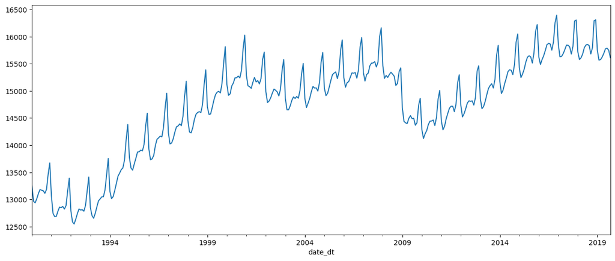

```python
ready_series.plot( figsize=(15, 6) )

plt.show()
```

Time series methods fundamentally deal with **autocorrelated data**. Autocorrelation refers to sequential observations are usually related to each other. The autocorrelation can be visualized with a **lag plot**.

The Pandas plotting function `pd.plotting.lag_plot()` assembles the data correctly to support visualizing the **LAGS** relationship.

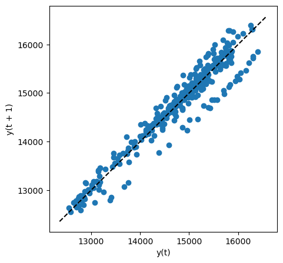

```python
fig, ax = plt.subplots(figsize=(5, 5))

pd.plotting.lag_plot( ready_series, lag=1, ax=ax )

plt.plot( ax.get_xlim(), ax.get_ylim(), 'k--' )

plt.show()
```

We do not have to just visualize the **sequential** observations in a lag plot. We can consider 2 lags.

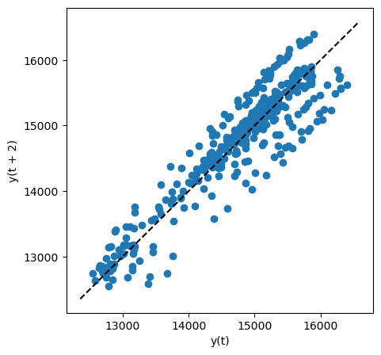

```python
fig, ax = plt.subplots(figsize=(5, 5))

pd.plotting.lag_plot( ready_series, lag=2, ax=ax )

plt.plot( ax.get_xlim(), ax.get_ylim(), 'k--' )

plt.show()
```

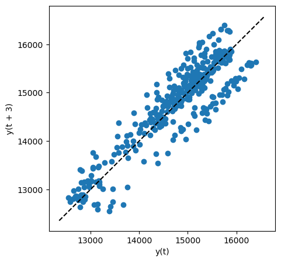

```python
fig, ax = plt.subplots(figsize=(5, 5))

pd.plotting.lag_plot( ready_series, lag=3, ax=ax )

plt.plot( ax.get_xlim(), ax.get_ylim(), 'k--' )

plt.show()
```

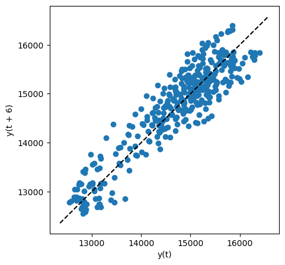

```python
fig, ax = plt.subplots(figsize=(5, 5))

pd.plotting.lag_plot( ready_series, lag=6, ax=ax )

plt.plot( ax.get_xlim(), ax.get_ylim(), 'k--' )

plt.show()
```

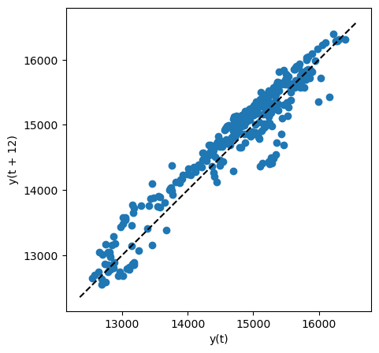

```python
fig, ax = plt.subplots(figsize=(5, 5))

pd.plotting.lag_plot( ready_series, lag=12, ax=ax )

plt.plot( ax.get_xlim(), ax.get_ylim(), 'k--' )

plt.show()
```

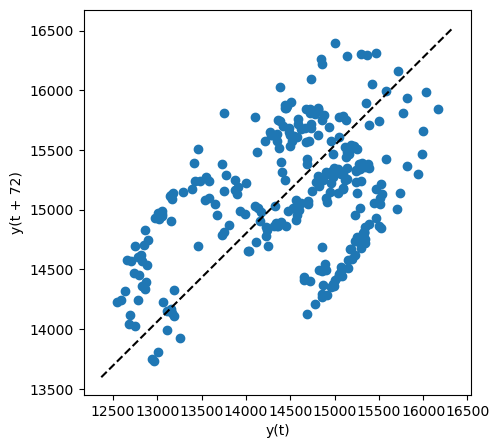

```python
fig, ax = plt.subplots(figsize=(5, 5))

pd.plotting.lag_plot( ready_series, lag=72, ax=ax )

plt.plot( ax.get_xlim(), ax.get_ylim(), 'k--' )

plt.show()
```

The lag plots can be summarized into a single figure through the **AUTOCORRELATION PLOT**.

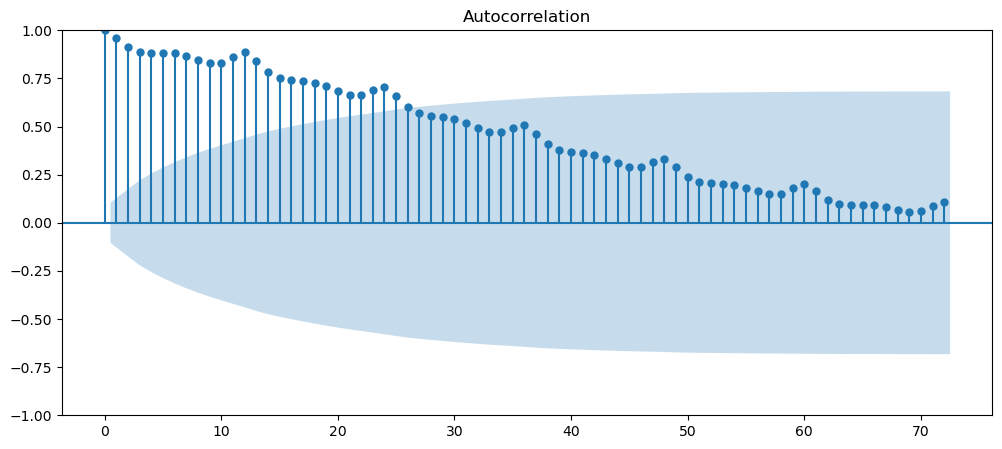

```python
fig, ax = plt.subplots(figsize=(12, 5))

sm.graphics.tsa.plot_acf( ready_series.values.squeeze(), lags=72, ax=ax )

plt.show()
```

## Time decomposition

Separate the **TREND** from the **SEASONAL** pattern within the data.

The classic decomposition methods are applied via the `sm.tsa.seasonal_decompose()`.

```python
retail_decompose = sm.tsa.seasonal_decompose( ready_series, model='additive')
```

Visualize the time series decomposition.

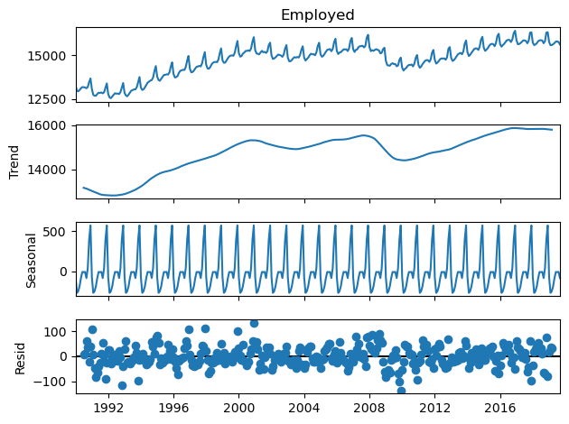

```python
fig = retail_decompose.plot()
```

The above figure is rather small. The size is increased below.

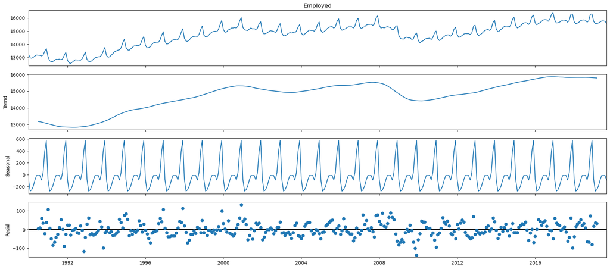

```python
plt.rcParams['figure.figsize'] = 18,8
plt.show()

fig = retail_decompose.plot()
```

We can extract the various components. For example, the `.seasonal` is provided below.

```python
retail_decompose.seasonal
```

```
date_dt
1990-01-01    -75.461230
1990-02-01   -273.051173
1990-03-01   -253.195856
1990-04-01   -190.219599
1990-05-01    -88.923022
                 ...
2019-05-01    -88.923022
2019-06-01    -10.388349
2019-07-01    -13.311661
2019-08-01     -9.992696
2019-09-01    -87.379333
Freq: MS, Name: seasonal, Length: 357, dtype: float64
```

If you subtract the `.seasonal` component from the raw data or the `.observed` values you will have the **SEASONALLY ADJUSTED** observations. Seasonally adjusted means the seasonal component is removed and we are examining the **MACRO** trend over time.

```python
df_decomp_retail = pd.DataFrame({'observed': retail_decompose.observed,
                                 'seasonal_adjusted': retail_decompose.observed - retail_decompose.seasonal},
                                index=ready_series.index)
```

```python
df_decomp_retail
```

| date_dt | observed | seasonal_adjusted |
| --- | --- | --- |
| 1990-01-01 | 13255.8 | 13331.261230 |
| 1990-02-01 | 12966.3 | 13239.351173 |
| 1990-03-01 | 12938.2 | 13191.395856 |
| 1990-04-01 | 13012.3 | 13202.519599 |
| 1990-05-01 | 13108.3 | 13197.223022 |
| ... | ... | ... |
| 2019-05-01 | 15691.6 | 15780.523022 |
| 2019-06-01 | 15775.5 | 15785.888349 |
| 2019-07-01 | 15785.9 | 15799.211661 |
| 2019-08-01 | 15749.5 | 15759.492696 |
| 2019-09-01 | 15611.3 | 15698.679333 |

357 rows × 2 columns

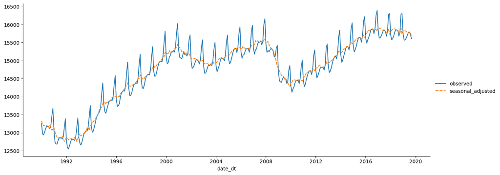

```python
sns.relplot(data = df_decomp_retail, kind='line', aspect=2.5)

plt.show()
```

We can also visualize the month-to-month variation with the MONTH PLOT.

The function is `sm.graphics.tsa.month_plot()`.

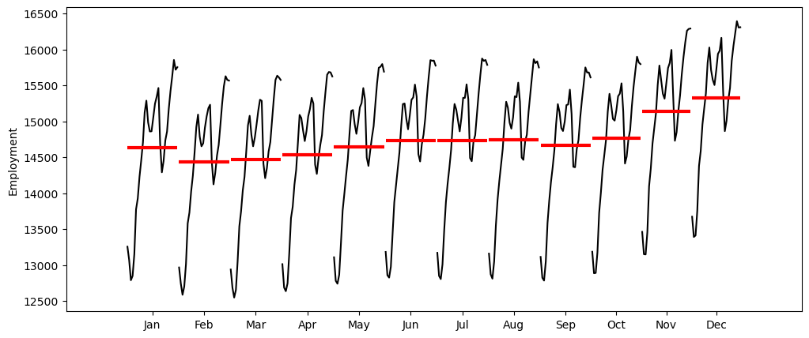

```python
fig, ax = plt.subplots(figsize=(12, 5))

sm.graphics.tsa.month_plot( ready_series, ylabel="Employment", ax=ax )

plt.show()
```

If we use the entire time series the month plot is clouded by the overall MACRO trend...instead we want to visualize the **DETRENDED** data.

The **DETRENDED** data is the `.observed` attribute minus the `.trend` attribute. However, the classical additive method has NaN values at the beginning and end of the series.

```python
retail_decompose.trend
```

```
date_dt
1990-01-01   NaN
1990-02-01   NaN
1990-03-01   NaN
1990-04-01   NaN
1990-05-01   NaN
              ..
2019-05-01   NaN
2019-06-01   NaN
2019-07-01   NaN
2019-08-01   NaN
2019-09-01   NaN
Freq: MS, Name: trend, Length: 357, dtype: float64
```

This also means the `.resid` (the error term) also has NaN at the beginning and end of the series.

```python
retail_decompose.resid
```

```
date_dt
1990-01-01   NaN
1990-02-01   NaN
1990-03-01   NaN
1990-04-01   NaN
1990-05-01   NaN
              ..
2019-05-01   NaN
2019-06-01   NaN
2019-07-01   NaN
2019-08-01   NaN
2019-09-01   NaN
Freq: MS, Name: resid, Length: 357, dtype: float64
```

If we make the MONTH plot using the `.seasonal` component directly...it's not very interesting from the ADDITIVE decomposition. The seasonal term is assumed to be constant over the years in the classical additive method!

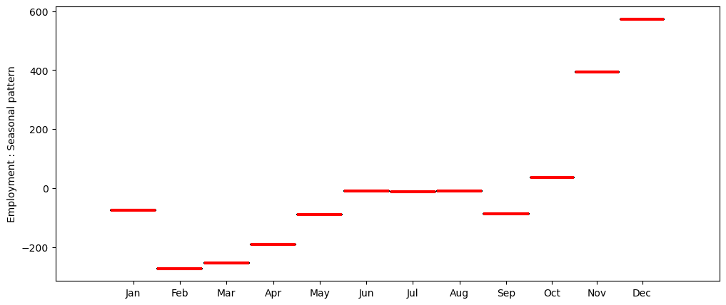

```python
fig, ax = plt.subplots(figsize=(12, 5))

sm.graphics.tsa.month_plot( retail_decompose.seasonal, ylabel="Employment : Seasonal pattern", ax=ax )

plt.show()
```

### Advanced decompositions

We can allow the seasonal pattern to change across years by using more advanced decomposition methods.

```python
from statsmodels.tsa.seasonal import STL
```

```python
retail_stl = STL( ready_series )
```

```python
retail_stl_fit = retail_stl.fit( )
```

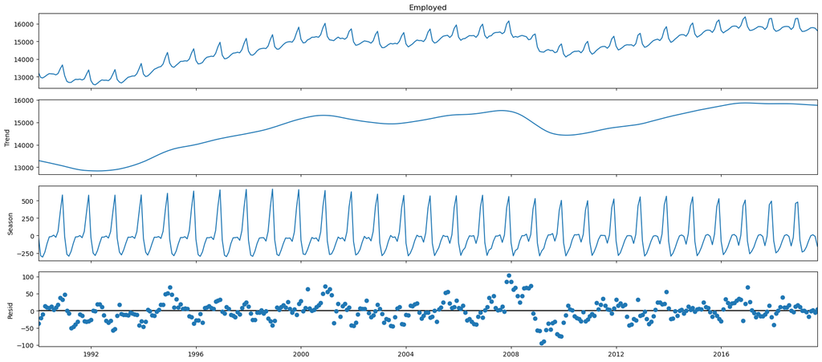

```python
fig = retail_stl_fit.plot()
```

We can extract the components just as before, so we can visualize the **seasonally adjusted data**.

```python
df_stl_retail = pd.DataFrame({"observed": retail_stl_fit.observed,
                              'seasonal_adjusted': retail_stl_fit.observed - retail_stl_fit.seasonal},
                             index=ready_series.index)
```

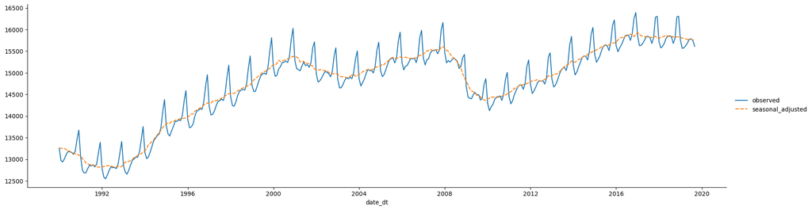

```python
sns.relplot(data = df_stl_retail, kind='line', aspect=3.5)

plt.show()
```

We no longer have any MISSINGS or NaNs in the `.trend` component with STL.

```python
retail_stl_fit.trend
```

```
date_dt
1990-01-01    13296.248875
1990-02-01    13276.085176
1990-03-01    13255.662673
1990-04-01    13234.986479
1990-05-01    13214.070964
                  ...
2019-05-01    15784.875120
2019-06-01    15778.842886
2019-07-01    15772.740656
2019-08-01    15766.582336
2019-09-01    15760.380262
Freq: MS, Name: trend, Length: 357, dtype: float64
```

It's easier to create the visuals for the **detrended** data.

```python
retail_detrend = retail_stl_fit.observed - retail_stl_fit.trend
```

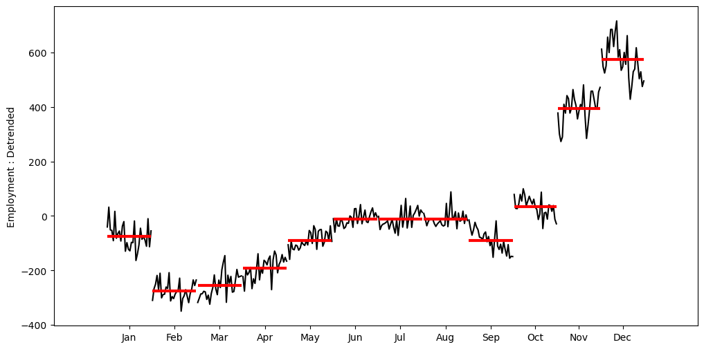

```python
fig, ax = plt.subplots(figsize=(12, 6))

sm.graphics.tsa.month_plot( retail_detrend, ylabel='Employment : Detrended', ax = ax)

plt.show()
```

We can further smooth the detrended data by also subtracting the **RESIDUAL** or **remainder**.

```python
retail_detrend_smooth = retail_stl_fit.observed - ( retail_stl_fit.trend + retail_stl_fit.resid )
```

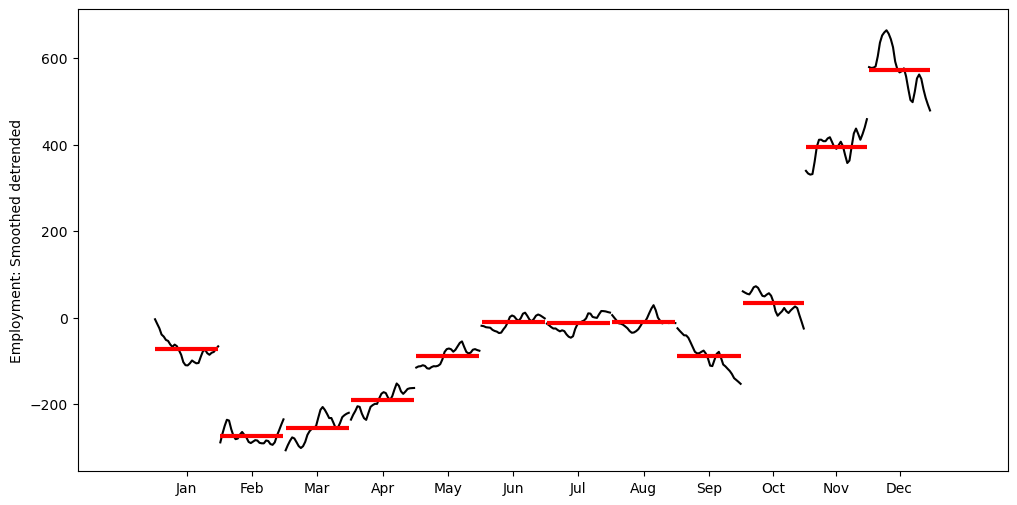

```python
fig, ax = plt.subplots(figsize=(12, 6))

sm.graphics.tsa.month_plot( retail_detrend_smooth, ylabel = 'Employment: Smoothed detrended', ax = ax)

plt.show()
```

We could have just made the above figure using the SEASONAL component directly from the STL decomposition.

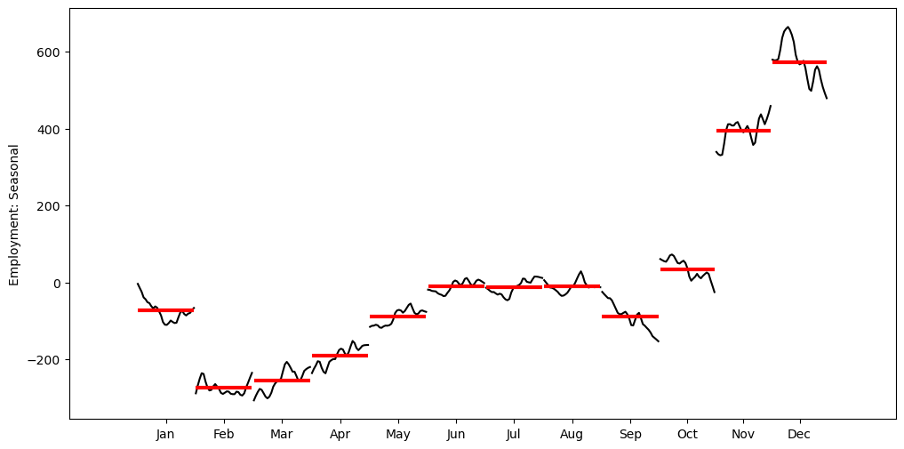

```python
fig, ax = plt.subplots(figsize=(12, 6))

sm.graphics.tsa.month_plot( retail_stl_fit.seasonal, ylabel = 'Employment: Seasonal', ax = ax)

plt.show()
```

## Conclusion

The report demonstated organizing the data for time series analysis, exploring the autocorrelation structure, and extracting the seasonal and trend components via decomposition.